https://www.kaggle.com/ufffnick/loan-prediction-dream-housing-finance https://datahack.analyticsvidhya.com/contest/all/ https://github.com/ritusri/Loan-Prediction-Problem/blob/master/loan_prediction%20(1).ipynb

# Caso de Estudio

Predecir la elegibilidad del préstamo para una empresa de financiación de viviendas "de ensueño".

La empresa Dream Housing Finance se ocupa de todo tipo de préstamos hipotecarios. Tienen presencia en todas las áreas urbanas, semiurbanas y rurales. El cliente primero solicita un préstamo hipotecario y luego la empresa valida la elegibilidad del cliente para el préstamo.

La empresa desea automatizar el proceso de elegibilidad del préstamo (en tiempo real) según los detalles del cliente proporcionados al completar el formulario de solicitud en línea. Estos detalles son género, estado civil, educación, número de dependientes, ingresos, monto del préstamo, historial crediticio y otros. Para automatizar este proceso, han proporcionado un conjunto de datos para identificar los segmentos de clientes que son elegibles para el monto del préstamo para que puedan dirigirse específicamente a estos clientes.

# Variable Description

TRAIN

Loan_ID Unique Loan ID Gender Male/ Female Married Applicant married (Y/N) Dependents Number of dependents Education Applicant Education (Graduate/ Under Graduate) Self_Employed Self employed (Y/N) ApplicantIncome Applicant income CoapplicantIncome Coapplicant income LoanAmount Loan amount in thousands Loan_Amount_Term Term of loan in months Credit_History Credit history meets guidelines Property_Area Urban/ Semi Urban/ Rural Loan_Status (Target) Loan approved (Y/N)

TEST

Loan_ID Unique Loan ID Gender Male/ Female Married Applicant married (Y/N) Dependents Number of dependents Education Applicant Education (Graduate/ Under Graduate) Self_Employed Self employed (Y/N) ApplicantIncome Applicant income CoapplicantIncome Coapplicant income LoanAmount Loan amount in thousands Loan_Amount_Term Term of loan in months Credit_History credit history meets guidelines Property_Area Urban/ Semi Urban/ Rural

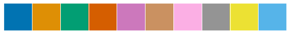

```python
import pandas as pd
import numpy as np
import seaborn as sns
import matplotlib.pyplot as plt
import matplotlib.axes
import dexplot as dxp

from sklearn.svm import SVC,LinearSVC, SVR
from sklearn.ensemble import RandomForestClassifier
from sklearn.naive_bayes import GaussianNB
from sklearn.ensemble import RandomForestRegressor
from sklearn.linear_model import LinearRegression, LogisticRegression
from sklearn.model_selection import GridSearchCV
from sklearn.feature_selection import SelectKBest, f_classif
#from sklearn.externals import joblib

from sklearn.metrics import roc_auc_score, precision_recall_fscore_support, classification_report
from sklearn.metrics import precision_recall_curve, confusion_matrix, roc_curve, auc

from scipy.stats import skew, kurtosis

from sklearn.dummy import DummyClassifier
from sklearn.model_selection import train_test_split, cross_val_score
from sklearn.preprocessing import OneHotEncoder

from IPython.core.interactiveshell import InteractiveShell
InteractiveShell.ast_node_interactivity = "all"

#plt.style.use('dark_background')
current_palette = sns.color_palette('colorblind')
sns.palplot(current_palette)
```

```python
def saca_metricas(y1, y2):#con esto sacamos la matriz de confusion, curva roc y la pintamos.
    print('matriz de confusión')
    print(confusion_matrix(y1, y2))
    print('accuracy')
    print(accuracy_score(y1, y2))
    print('precision')
    print(precision_score(y1, y2))
    print('recall')
    print(recall_score(y1, y2))
    print('f1')
    print(f1_score(y1, y2))
    false_positive_rate, recall, thresholds = roc_curve(y1, y2)
    roc_auc = auc(false_positive_rate, recall)
    print('AUC')
    print(roc_auc)
    plt.plot(false_positive_rate, recall, 'b')
    plt.plot([0, 1], [0, 1], 'r--')
    plt.title('AUC = %0.2f' % roc_auc)
```

IMPORTAR DATOS

```python
data_set = pd.read_csv('C:/Users/raul/Documents/Data Science Proyectos/Datos/train_banco.csv')
```

```python
data_set.info()
```

```
<class 'pandas.core.frame.DataFrame'>
RangeIndex: 614 entries, 0 to 613
Data columns (total 13 columns):
 #   Column             Non-Null Count  Dtype
---  ------             --------------  -----
 0   Loan_ID            614 non-null    object
 1   Gender             601 non-null    object
 2   Married            611 non-null    object
 3   Dependents         599 non-null    object
 4   Education          614 non-null    object
 5   Self_Employed      582 non-null    object
 6   ApplicantIncome    614 non-null    int64
 7   CoapplicantIncome  614 non-null    float64
 8   LoanAmount         592 non-null    float64
 9   Loan_Amount_Term   600 non-null    float64
 10  Credit_History     564 non-null    float64
 11  Property_Area      614 non-null    object
 12  Loan_Status        614 non-null    object
dtypes: float64(4), int64(1), object(8)
memory usage: 62.5+ KB
```

```python
test = pd.read_csv('C:/Users/raul/Documents/Data Science Proyectos/Datos/test_banco.csv')
```

```python
test.info()
```

```
<class 'pandas.core.frame.DataFrame'>
RangeIndex: 367 entries, 0 to 366
Data columns (total 12 columns):
 #   Column             Non-Null Count  Dtype
---  ------             --------------  -----
 0   Loan_ID            367 non-null    object
 1   Gender             356 non-null    object
 2   Married            367 non-null    object
 3   Dependents         357 non-null    object
 4   Education          367 non-null    object
 5   Self_Employed      344 non-null    object
 6   ApplicantIncome    367 non-null    int64
 7   CoapplicantIncome  367 non-null    int64
 8   LoanAmount         362 non-null    float64
 9   Loan_Amount_Term   361 non-null    float64
 10  Credit_History     338 non-null    float64
 11  Property_Area      367 non-null    object
dtypes: float64(3), int64(2), object(7)
memory usage: 34.5+ KB
```

```python
data_set.LoanAmount = data_set.LoanAmount*1000
```

```python
data_set.Loan_Status.value_counts(normalize = True).reset_index()
```

|  | index | Loan_Status |
| --- | --- | --- |
| 0 | Y | 0.687296 |
| 1 | N | 0.312704 |

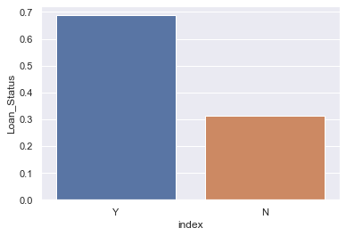

```python
sns.barplot(data = data_set.Loan_Status.value_counts(normalize = True).reset_index(),
            x = 'index',
            y = 'Loan_Status',
            #palette=current_palette)
           )
```

Se puede observar que la base de datos no esta balanceada, 69% se le fue aprobado el prestamo mientras que el 31% restante no.

```python
data_set.info()
```

```
<class 'pandas.core.frame.DataFrame'>
RangeIndex: 614 entries, 0 to 613
Data columns (total 13 columns):
 #   Column             Non-Null Count  Dtype
---  ------             --------------  -----
 0   Loan_ID            614 non-null    object
 1   Gender             601 non-null    object
 2   Married            611 non-null    object
 3   Dependents         599 non-null    object
 4   Education          614 non-null    object
 5   Self_Employed      582 non-null    object
 6   ApplicantIncome    614 non-null    int64
 7   CoapplicantIncome  614 non-null    float64
 8   LoanAmount         592 non-null    float64
 9   Loan_Amount_Term   600 non-null    float64
 10  Credit_History     564 non-null    float64
 11  Property_Area      614 non-null    object
 12  Loan_Status        614 non-null    object
dtypes: float64(4), int64(1), object(8)
memory usage: 62.5+ KB
```

```python
col = data_set.columns[1:data_set.shape[1]-1]
col
```

```
Index(['Gender', 'Married', 'Dependents', 'Education', 'Self_Employed',
       'ApplicantIncome', 'CoapplicantIncome', 'LoanAmount',
       'Loan_Amount_Term', 'Credit_History', 'Property_Area'],
      dtype='object')
```

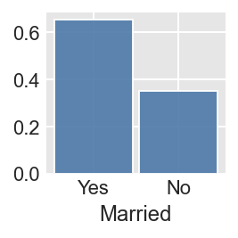

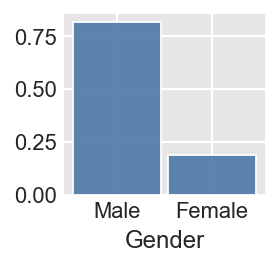

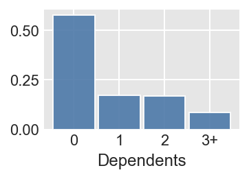

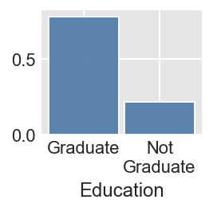

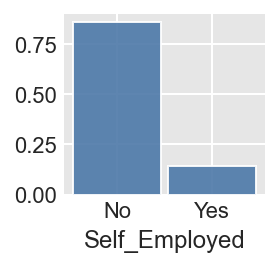

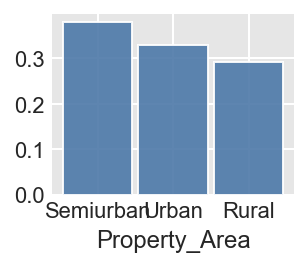

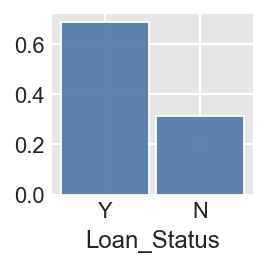

```python
dxp.count(val='Married', data=data_set, normalize=True)
dxp.count(val='Gender', data=data_set, normalize=True)
dxp.count(val='Dependents', data=data_set, normalize=True)
dxp.count(val='Education', data=data_set, normalize=True)
dxp.count(val='Self_Employed', data=data_set, normalize=True)
dxp.count(val='Property_Area', data=data_set, normalize=True)
dxp.count(val='Loan_Status', data=data_set, normalize=True)
```

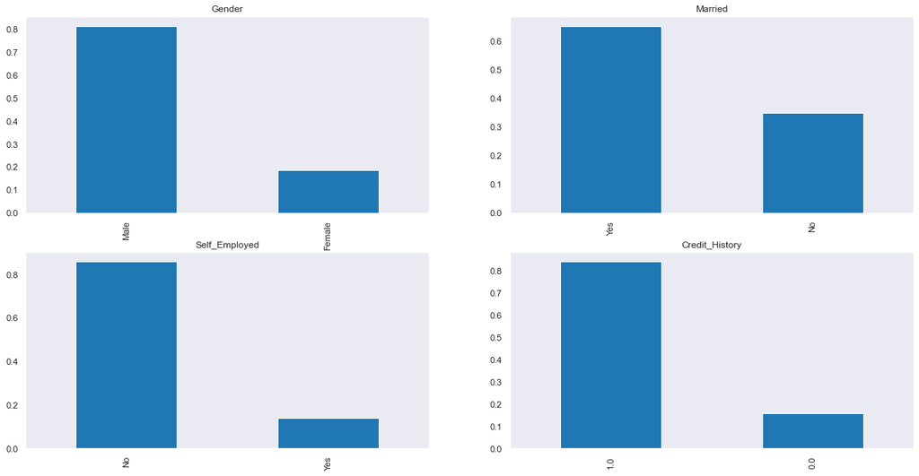

```python
plt.figure(1)
plt.subplot(221)
data_set['Gender'].value_counts(normalize=True).plot.bar(figsize=(20,10), title= 'Gender')

plt.subplot(222)
data_set['Married'].value_counts(normalize=True).plot.bar(title= 'Married')

plt.subplot(223)
data_set['Self_Employed'].value_counts(normalize=True).plot.bar(title= 'Self_Employed')

plt.subplot(224)
data_set['Credit_History'].value_counts(normalize=True).plot.bar(title= 'Credit_History')

plt.show()
```

El data set NO esta balanceado, lo que traera problemas en el accuracy.

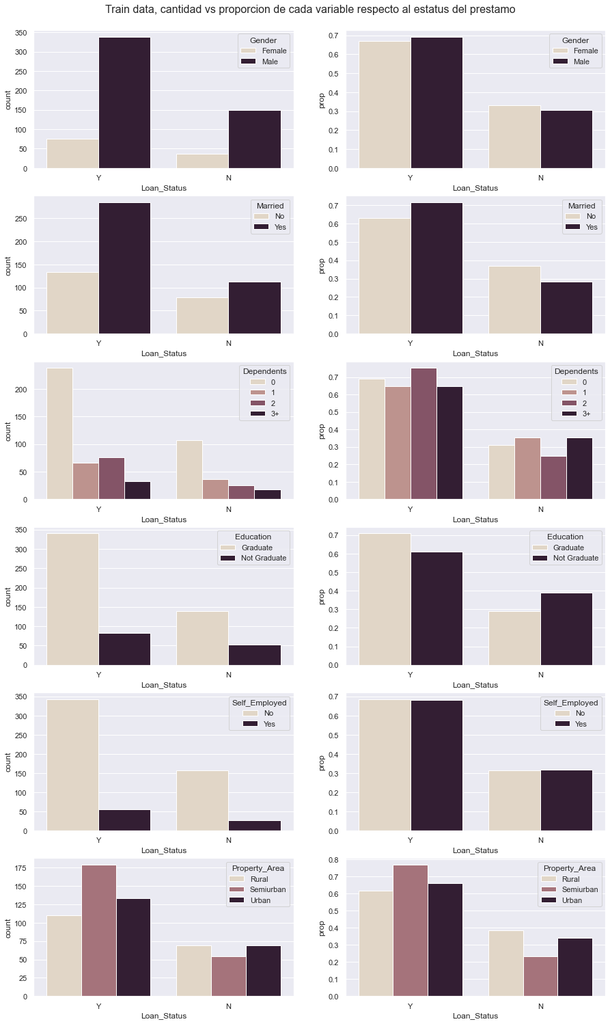

```python
def prop_check(data):
    f, axes = plt.subplots(6,2,figsize= (15,26))
    plt.suptitle('Train data, cantidad vs proporcion de cada variable respecto al estatus del prestamo', size =16, y = 0.9)
    col = data.columns[1:data.shape[1]-1]
    r = 0
    for i in col:
        if (data.dtypes == 'object')[i]:
            data_prop = (data['Loan_Status']
                          .groupby(data[i])
                          .value_counts(normalize = True)
                          .rename('prop')
                          .reset_index())
            sns.countplot(data = data,
                          x ='Loan_Status',
                          hue = i,
                          ax = axes[r,0],
                          hue_order=data_prop[i].unique(),
                          palette="ch:.25")
            sns.barplot(data = data_prop,
                        x = 'Loan_Status',
                        y = 'prop',
                        hue = i,
                        ax = axes[r,1],
                        palette="ch:.25")
            r = r+1
prop_check(data_set)
```

```python
data_set.info()
```

```
<class 'pandas.core.frame.DataFrame'>
RangeIndex: 614 entries, 0 to 613
Data columns (total 13 columns):
 #   Column             Non-Null Count  Dtype
---  ------             --------------  -----
 0   Loan_ID            614 non-null    object
 1   Gender             601 non-null    object
 2   Married            611 non-null    object
 3   Dependents         599 non-null    object
 4   Education          614 non-null    object
 5   Self_Employed      582 non-null    object
 6   ApplicantIncome    614 non-null    int64
 7   CoapplicantIncome  614 non-null    float64
 8   LoanAmount         592 non-null    float64
 9   Loan_Amount_Term   600 non-null    float64
 10  Credit_History     564 non-null    float64
 11  Property_Area      614 non-null    object
 12  Loan_Status        614 non-null    object
dtypes: float64(4), int64(1), object(8)
memory usage: 62.5+ KB
```

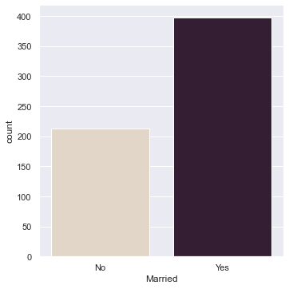

```python
sns.catplot(x="Married", kind="count", palette="ch:.25", data=data_set)
```

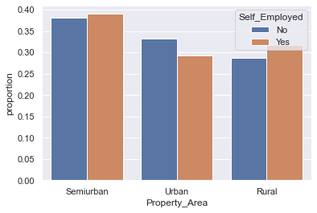

```python
import pandas as pd
import seaborn as sns

df = data_set
x, y, hue = "Property_Area", "proportion", "Self_Employed"
hue_order = ["No", "Yes"]
palette="ch:.25"

(df[x]
    .groupby(df[hue])
    .value_counts(normalize=True)
    .rename(y)
    .reset_index()
    .pipe((sns.barplot, "data"), x=x, y=y, hue=hue))
```

Como indican los gráficos, en su mayoría se distribuyen de manera uniforme entre las características, también podemos aprender que no existe una correlación obvia en esta etapa, hagamos que la columna **Loan_ID** sea un índice para un análisis adicional (también podríamos eliminarlo)

```python
data_set.head()
```

|  | Loan_ID | Gender | Married | Dependents | Education | Self_Employed | ApplicantIncome | CoapplicantIncome | LoanAmount | Loan_Amount_Term | Credit_History | Property_Area | Loan_Status |
| --- | --- | --- | --- | --- | --- | --- | --- | --- | --- | --- | --- | --- | --- |
| 0 | LP001002 | Male | No | 0 | Graduate | No | 5849 | 0.0 | NaN | 360.0 | 1.0 | Urban | Y |
| 1 | LP001003 | Male | Yes | 1 | Graduate | No | 4583 | 1508.0 | 128000.0 | 360.0 | 1.0 | Rural | N |
| 2 | LP001005 | Male | Yes | 0 | Graduate | Yes | 3000 | 0.0 | 66000.0 | 360.0 | 1.0 | Urban | Y |
| 3 | LP001006 | Male | Yes | 0 | Not Graduate | No | 2583 | 2358.0 | 120000.0 | 360.0 | 1.0 | Urban | Y |
| 4 | LP001008 | Male | No | 0 | Graduate | No | 6000 | 0.0 | 141000.0 | 360.0 | 1.0 | Urban | Y |

```python
def make_index(df):
    df.set_index('Loan_ID', inplace=True)
    return df
data_set = make_index(data_set)
```

```python
data_set.head()
```

| Loan_ID | Gender | Married | Dependents | Education | Self_Employed | ApplicantIncome | CoapplicantIncome | LoanAmount | Loan_Amount_Term | Credit_History | Property_Area | Loan_Status |
| --- | --- | --- | --- | --- | --- | --- | --- | --- | --- | --- | --- | --- |
| LP001002 | Male | No | 0 | Graduate | No | 5849 | 0.0 | NaN | 360.0 | 1.0 | Urban | Y |
| LP001003 | Male | Yes | 1 | Graduate | No | 4583 | 1508.0 | 128000.0 | 360.0 | 1.0 | Rural | N |
| LP001005 | Male | Yes | 0 | Graduate | Yes | 3000 | 0.0 | 66000.0 | 360.0 | 1.0 | Urban | Y |
| LP001006 | Male | Yes | 0 | Not Graduate | No | 2583 | 2358.0 | 120000.0 | 360.0 | 1.0 | Urban | Y |
| LP001008 | Male | No | 0 | Graduate | No | 6000 | 0.0 | 141000.0 | 360.0 | 1.0 | Urban | Y |

```python
data_set.dropna(inplace=True)
```

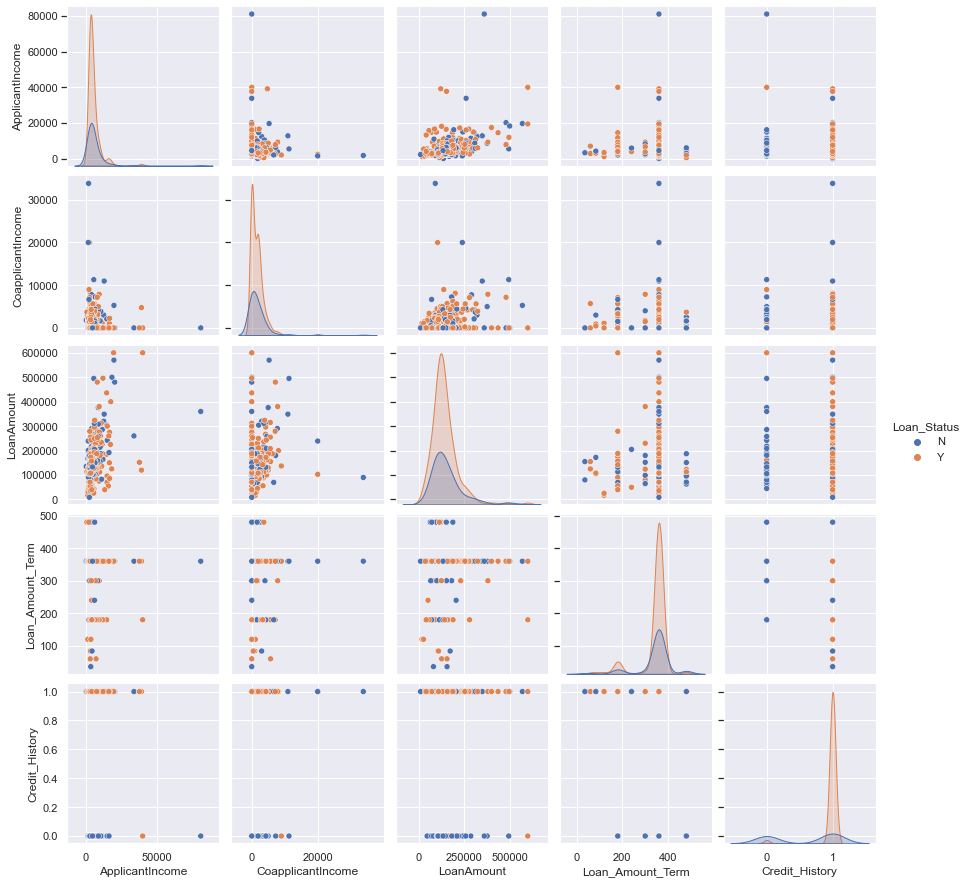

```python
sns.pairplot(data_set, hue = 'Loan_Status')
```

Podemos ver aquí el primer signo de alguna correlación con las características de ingresos y el monto del préstamo Vamos a trabajarlos para que sean más amigables con los modelos (normalmente distribuidos y con media 0)

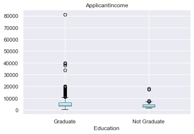

```python
data_set.boxplot(column='ApplicantIncome', by = 'Education')
plt.suptitle("")
```

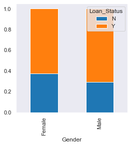

```python
Gender=pd.crosstab(data_set['Gender'],data_set['Loan_Status'])
Gender.div(Gender.sum(1).astype(float), axis=0).plot(kind="bar", stacked=True, figsize=(4,4))
```

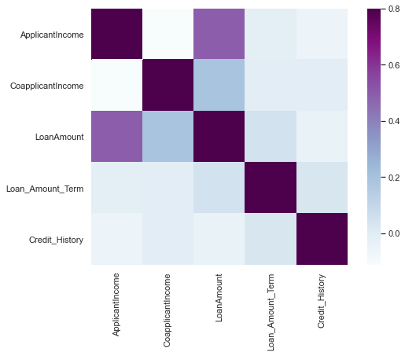

```python
matrix = data_set.corr()
f, ax = plt.subplots(figsize=(9, 6))
sns.heatmap(matrix, vmax=.8, square=True, cmap="BuPu");
```

## Categorizar numéricamente columnas de objetos por nombre de columna

Cada columna traducida a valor binario Columnas de múltiples variables seleccionadas con columnas ficticias Eliminar los duplicados en los datos

```python
def categorize(df):
    df.Gender.replace({'Male': 1, 'Female': 0}, inplace = True)
    df.Married.replace({'Yes': 1, 'No': 0}, inplace = True)
    df.Education.replace({'Graduate': 1, 'Not Graduate': 0}, inplace = True)
    df.Self_Employed.replace({'Yes': 1, 'No': 0}, inplace = True)
    df = df.join(pd.get_dummies(df.Dependents, prefix='Dependents'))
    df.drop(columns= ['Dependents', 'Dependents_3+'], inplace=True)#dependents restantes respecto a si tiene 3 o mas dependientes
    df = df.join(pd.get_dummies(df.Property_Area, prefix='Property_Area'))
    df.drop(columns= ['Property_Area', 'Property_Area_Rural'], inplace=True)
    return df
```

```python
data_set = categorize(data_set)
```

```python
data_set.Loan_Status.replace({'Y': 1, 'N':0}, inplace=True)
```

```python
data_set['CoapplicantIncome'] = pd.to_numeric(data_set['CoapplicantIncome'])
data_set['LoanAmount'] = pd.to_numeric(data_set['LoanAmount'])
data_set['Loan_Amount_Term'] = pd.to_numeric(data_set['Loan_Amount_Term'])
data_set['Credit_History'] = pd.to_numeric(data_set['Credit_History'])
```

```python
data_set.info()
```

```
<class 'pandas.core.frame.DataFrame'>
Index: 480 entries, LP001003 to LP002990
Data columns (total 15 columns):
 #   Column                   Non-Null Count  Dtype
---  ------                   --------------  -----
 0   Gender                   480 non-null    int64
 1   Married                  480 non-null    int64
 2   Education                480 non-null    int64
 3   Self_Employed            480 non-null    int64
 4   ApplicantIncome          480 non-null    int64
 5   CoapplicantIncome        480 non-null    float64
 6   LoanAmount               480 non-null    float64
 7   Loan_Amount_Term         480 non-null    float64
 8   Credit_History           480 non-null    float64
 9   Loan_Status              480 non-null    int64
 10  Dependents_0             480 non-null    uint8
 11  Dependents_1             480 non-null    uint8
 12  Dependents_2             480 non-null    uint8
 13  Property_Area_Semiurban  480 non-null    uint8
 14  Property_Area_Urban      480 non-null    uint8
dtypes: float64(4), int64(6), uint8(5)
memory usage: 63.6+ KB
```

```python
data_set.isnull().sum()
```

```
Gender                     0
Married                    0
Education                  0
Self_Employed              0
ApplicantIncome            0
CoapplicantIncome          0
LoanAmount                 0
Loan_Amount_Term           0
Credit_History             0
Loan_Status                0
Dependents_0               0
Dependents_1               0
Dependents_2               0
Property_Area_Semiurban    0
Property_Area_Urban        0
dtype: int64
```

Lo mismo para los datos de testeo:

```python
test.LoanAmount = test.LoanAmount*1000
```

```python
test = make_index(test)
```

```python
test.isnull().values.any()
```

```
True
```

```python
test.isnull().sum()
```

```
Gender               11
Married               0
Dependents           10
Education             0
Self_Employed        23
ApplicantIncome       0
CoapplicantIncome     0
LoanAmount            5
Loan_Amount_Term      6
Credit_History       29
Property_Area         0
dtype: int64
```

Si hago un drop, tendre un problema de datos al momento de subir el material a la web. Tres Variables son las 'Problematicas': Gender, Self_Employed, Credit_History. #test.dropna(inplace=True)

```python
test = categorize(test)
```

```python
test['Gender'] = test['Gender'].replace(np.nan, test['Gender'].mean())
```

```python
test['Self_Employed'] = test['Self_Employed'].replace(np.nan, test['Self_Employed'].mean())
```

```python
test['Credit_History'] = test['Credit_History'].replace(np.nan, test['Credit_History'].mean())
```

```python
test['LoanAmount'] = test['LoanAmount'].replace(np.nan, test['LoanAmount'].mean())
```

```python
test['Loan_Amount_Term'] = test['Loan_Amount_Term'].replace(np.nan, test['Loan_Amount_Term'].mean())
```

```python
test.info()
```

```
<class 'pandas.core.frame.DataFrame'>
Index: 367 entries, LP001015 to LP002989
Data columns (total 14 columns):
 #   Column                   Non-Null Count  Dtype
---  ------                   --------------  -----
 0   Gender                   367 non-null    float64
 1   Married                  367 non-null    int64
 2   Education                367 non-null    int64
 3   Self_Employed            367 non-null    float64
 4   ApplicantIncome          367 non-null    int64
 5   CoapplicantIncome        367 non-null    int64
 6   LoanAmount               367 non-null    float64
 7   Loan_Amount_Term         367 non-null    float64
 8   Credit_History           367 non-null    float64
 9   Dependents_0             367 non-null    uint8
 10  Dependents_1             367 non-null    uint8
 11  Dependents_2             367 non-null    uint8
 12  Property_Area_Semiurban  367 non-null    uint8
 13  Property_Area_Urban      367 non-null    uint8
dtypes: float64(5), int64(4), uint8(5)
memory usage: 40.5+ KB
```

# Variables a transformar: ApplicantIncome CoapplicantIncome LoanAmount Loan_Amount_Term

# Seleccion de modelos y normalización de variables:

Añadiendo nuevas funciones: naive estimation del rendimiento mensual del préstamo (LoanAmount / Loan_Amount_Term) normalizada y con ln () vamos a obtener la distribución lo más cerca posible de la distribución normal ingreso total (ApplicantIncome + CoaplicantIncome) normalizado y con ln () vamos a obtener la distribución lo más cerca posible de la distribución normal. Completando la transformación de las variables para la aplicación de modelos.

LoanAmount: Monto en $ del prestamo.

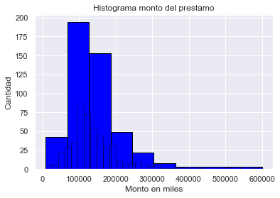

```python
# Histograma en con mayor detalle.
plt.hist(data_set['LoanAmount'], color = 'blue', edgecolor = 'black',
         )

# seaborn histogram
sns.distplot(data_set['LoanAmount'], hist=True, kde=False,
            color = 'blue',
             hist_kws={'edgecolor':'black'})
# Add labels
plt.title('Histograma monto del prestamo')
plt.xlabel('Monto en miles')
plt.ylabel('Cantidad')
```

Term of loan in months: Plazo del préstamo en meses.

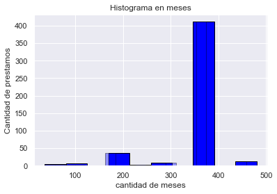

```python
# Histograma en con mayor detalle.
plt.hist(data_set['Loan_Amount_Term'], color = 'blue', edgecolor = 'black',
         )

# seaborn histogram
sns.distplot(data_set['Loan_Amount_Term'], hist=True, kde=False,
            color = 'blue',
             hist_kws={'edgecolor':'black'})
# Add labels
plt.title('Histograma en meses')
plt.xlabel('cantidad de meses')
plt.ylabel('Cantidad de prestamos')
```

# Variables nuevas

Data Normalization Normalization is a rescaling of the data from the original range so that all values are within the new range of 0 and 1.

Normalization requires that you know or are able to accurately estimate the minimum and maximum observable values. You may be able to estimate these values from your available data.

Voy a evitar generar mayo variables categoricas dado que se trata de un modelo de categorización y por ejemplo los arboles crecerían en un solo sentido.

ln_monthly_return: El monto del prestamo respecto meses, normalizado. Puntualización habra que tratar LoanAmount y Loan_Amount_Term ln_total_income: Total de ingreso del hogar. suma de ApplicantIncome + CoapplicantIncome ln_LoanAmount: Normalizaciòn del loanAmount. SE ELIMINA loan Amount

```python
def add_feat(df):
    ln_monthly_return = np.log(df.LoanAmount/df.Loan_Amount_Term)
    df['ln_monthly_return'] = (ln_monthly_return - np.mean(ln_monthly_return))/(np.std(ln_monthly_return)/np.sqrt(len(ln_monthly_return)))

    ln_total_monthly_income = np.log(df.ApplicantIncome + df.CoapplicantIncome)
    df['ln_total_income'] = (ln_total_monthly_income - np.mean(ln_total_monthly_income))/(np.std(ln_total_monthly_income)/np.sqrt(len(ln_total_monthly_income)))

    ln_LoanAmount = np.log(1000*df.LoanAmount)
    df['ln_LoanAmount'] = (ln_LoanAmount - np.mean(ln_LoanAmount))/(np.std(ln_LoanAmount)/np.sqrt(len(ln_LoanAmount)))
    ln_monthly_return = np.log(df.LoanAmount/df.Loan_Amount_Term)

    return df
```

```python
data_set = add_feat(data_set)
```

```python
test = add_feat(test)
```

```python
from sklearn import preprocessing
```

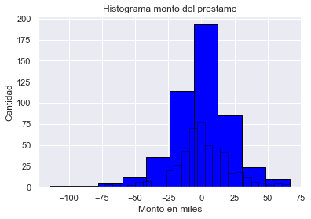

```python
# matplotlib histogram
plt.hist(data_set['ln_LoanAmount'], color = 'blue', edgecolor = 'black',
         )

# seaborn histogram
sns.distplot(data_set['ln_LoanAmount'], hist=True, kde=False,
            color = 'blue',
             hist_kws={'edgecolor':'black'})
# Add labels
plt.title('Histograma monto del prestamo')
plt.xlabel('Monto en miles')
plt.ylabel('Cantidad')
```

```python
data_set.info()
```

```
<class 'pandas.core.frame.DataFrame'>
Index: 480 entries, LP001003 to LP002990
Data columns (total 18 columns):
 #   Column                   Non-Null Count  Dtype
---  ------                   --------------  -----
 0   Gender                   480 non-null    int64
 1   Married                  480 non-null    int64
 2   Education                480 non-null    int64
 3   Self_Employed            480 non-null    int64
 4   ApplicantIncome          480 non-null    int64
 5   CoapplicantIncome        480 non-null    float64
 6   LoanAmount               480 non-null    float64
 7   Loan_Amount_Term         480 non-null    float64
 8   Credit_History           480 non-null    float64
 9   Loan_Status              480 non-null    int64
 10  Dependents_0             480 non-null    uint8
 11  Dependents_1             480 non-null    uint8
 12  Dependents_2             480 non-null    uint8
 13  Property_Area_Semiurban  480 non-null    uint8
 14  Property_Area_Urban      480 non-null    uint8
 15  ln_monthly_return        480 non-null    float64
 16  ln_total_income          480 non-null    float64
 17  ln_LoanAmount            480 non-null    float64
dtypes: float64(7), int64(6), uint8(5)
memory usage: 74.8+ KB
```

lets check the new features distributions

Definicion de una función par ver como distribuyen las nuevas variables

```python
def norm_plt(df):
    f, axes = plt.subplots(3,2,figsize= (12,15),squeeze=False)

    ###### total income ########
    sns.distplot(df.ln_total_income
                 ,ax=axes[0,0]).set_title('ln(total_income) norm distribution')
    #axes[0,0].set_xlim(-100,100)
    axes[0,0].text(0.03, 0.85,
                   'skew: {0:0.2}\nkurtosis: {1:0.2f}'
                   .format(skew(df.ln_total_income),
                                          kurtosis(df.ln_total_income)),
                   horizontalalignment='left',
                   verticalalignment='bottom',
                   transform=axes[0,0].transAxes,
                   bbox={'facecolor': 'white'})
    sns.distplot((df.ApplicantIncome+df.CoapplicantIncome),
                 ax=axes[0,1]).set_title('total_income distribution')
    axes[0,1].text(0.7, 0.85,
                   'skew: {0:0.2f}\nkurtosis: {1:0.2f}'
                   .format(skew(df.ApplicantIncome+df.CoapplicantIncome),
                           kurtosis(df.ApplicantIncome+df.CoapplicantIncome)),
                   horizontalalignment='left',
                   verticalalignment='bottom',
                   transform=axes[0,1].transAxes,
                   bbox={'facecolor': 'white'})

    ####### monthly return ###########
    sns.distplot(df.ln_monthly_return,
                 ax=axes[1,0]).set_title('ln(monthly_return) norm distribution')
    #axes[1,0].set_xlim(-100,100)
    axes[1,0].text(0.03, 0.85,
                   'skew: {0:0.2}\nkurtosis: {1:0.2f}'
                   .format(skew(df.ln_monthly_return),
                           kurtosis(df.ln_monthly_return)),
                   horizontalalignment='left',
                   verticalalignment='bottom',
                   transform=axes[1,0].transAxes,
                   bbox={'facecolor': 'white'})

    sns.distplot((1000*df.LoanAmount/df.Loan_Amount_Term),
                 ax=axes[1,1]).set_title('monthly_return distribution')
    axes[1,1].text(0.7, 0.85,
                   'skew: {0:0.2f}\nkurtosis: {1:0.2f}'
                   .format(skew(df.LoanAmount/df.Loan_Amount_Term),
                           kurtosis(df.LoanAmount/df.Loan_Amount_Term)),
                   horizontalalignment='left',
                   verticalalignment='bottom',
                   transform=axes[1,1].transAxes,
                   bbox={'facecolor': 'white'})

    ###### norm ln_LoanAmount ########
    sns.distplot(df.ln_LoanAmount
                 ,ax=axes[2,0]).set_title('ln(LoanAmount) norm distribution')
    #axes[2,0].set_xlim(-100,100)
    axes[2,0].text(0.03, 0.85,
                   'skew: {0:0.2}\nkurtosis: {1:0.2f}'
                   .format(skew(df.ln_LoanAmount),
                                          kurtosis(df.ln_LoanAmount)),
                   horizontalalignment='left',
                   verticalalignment='bottom',
                   transform=axes[2,0].transAxes,
                   bbox={'facecolor': 'white'})
    sns.distplot((df.LoanAmount),
                 ax=axes[2,1]).set_title('LoanAmount distribution')
    axes[2,1].text(0.7, 0.85,
                   'skew: {0:0.2f}\nkurtosis: {1:0.2f}'
                   .format(skew(df.LoanAmount),
                           kurtosis(df.LoanAmount)),
                   horizontalalignment='left',
                   verticalalignment='bottom',
                   transform=axes[2,1].transAxes,
                   bbox={'facecolor': 'white'})


    ####### adding grid to the graph#########
    for i in range(3):
        for j in range(2):
            axes[i,j].grid(b=True, which='both', axis='both', color='grey', linestyle = '--', linewidth = '0.3')
```

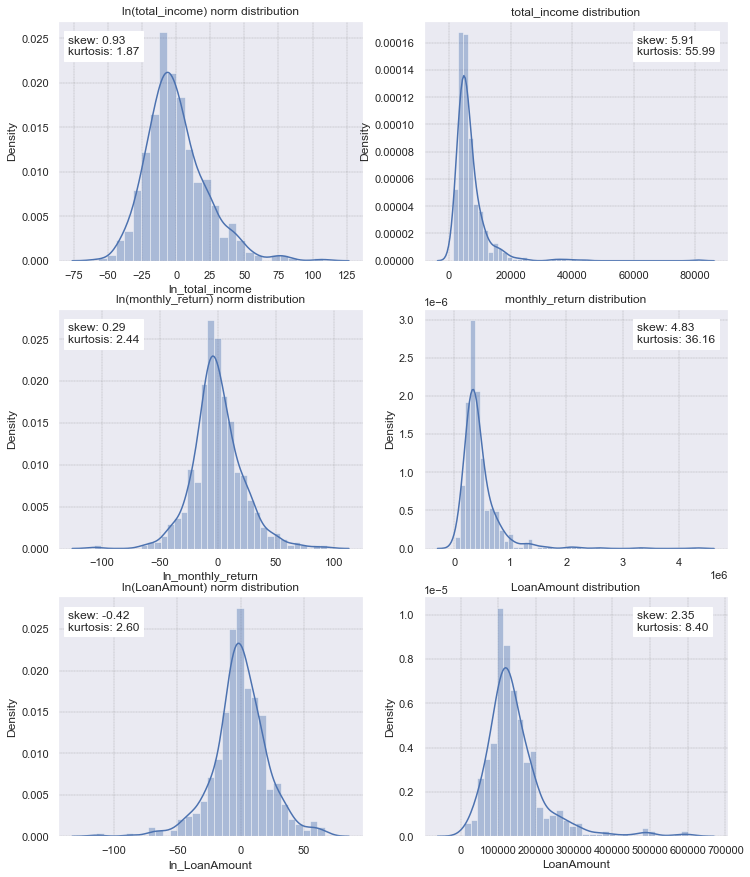

```python
norm_plt(data_set)
```

El sesgo y la curtosis están mucho más cerca de 0, como se esperaba de la distribución normal normalizada. ahora dejemos de lado las características no significativas que dependen de las nuevas características creadas anteriormente. Encontré en ejecuciones anteriores que los casados y los dependientes también son despreciables.

Variables a transformar: ApplicantIncome CoapplicantIncome Loan_Amount_Term

```python
data_set.info()
```

```
<class 'pandas.core.frame.DataFrame'>
Index: 480 entries, LP001003 to LP002990
Data columns (total 18 columns):
 #   Column                   Non-Null Count  Dtype
---  ------                   --------------  -----
 0   Gender                   480 non-null    int64
 1   Married                  480 non-null    int64
 2   Education                480 non-null    int64
 3   Self_Employed            480 non-null    int64
 4   ApplicantIncome          480 non-null    int64
 5   CoapplicantIncome        480 non-null    float64
 6   LoanAmount               480 non-null    float64
 7   Loan_Amount_Term         480 non-null    float64
 8   Credit_History           480 non-null    float64
 9   Loan_Status              480 non-null    int64
 10  Dependents_0             480 non-null    uint8
 11  Dependents_1             480 non-null    uint8
 12  Dependents_2             480 non-null    uint8
 13  Property_Area_Semiurban  480 non-null    uint8
 14  Property_Area_Urban      480 non-null    uint8
 15  ln_monthly_return        480 non-null    float64
 16  ln_total_income          480 non-null    float64
 17  ln_LoanAmount            480 non-null    float64
dtypes: float64(7), int64(6), uint8(5)
memory usage: 74.8+ KB
```

#### Eliminaciòn de variables ya transformadas:

```python
dropit=['LoanAmount', #Se elimina porque ya esta normalizada en ln_LoanAmount
        #'Loan_Amount_Term',
        #'ApplicantIncome',
        #'CoapplicantIncome',
        #'Married',
        #'Dependents_0',
        #'Dependents_1',
        #'Dependents_2'
       ]
data_set.drop(columns=dropit,
           inplace=True)
```

```python
# data_set['loanamountcuadrado'] = np.vectorize(fx2)(data_set['LoanAmount'], data_set['LoanAmount'])
# test['loanamountcuadrado'] = np.vectorize(fx2)(test['LoanAmount'], test['LoanAmount'])
```

```python
test.drop(columns=dropit,
           inplace=True)
```

Trabajo con la variable: Loan_Amount_Term

```python
x=data_set['Loan_Amount_Term']
x.describe()
```

```
count    480.000000
mean     342.050000
std       65.212401
min       36.000000
25%      360.000000
50%      360.000000
75%      360.000000
max      480.000000
Name: Loan_Amount_Term, dtype: float64
```

```python
#len(set(x))
```

```python
x=data_set['Loan_Amount_Term']
y = np.bincount(x)
ii = np.nonzero(y)[0]
```

```python
np.vstack((ii,y[ii])).T
```

```
array([[ 36,   2],
       [ 60,   2],
       [ 84,   3],
       [120,   3],
       [180,  36],
       [240,   2],
       [300,   9],
       [360, 411],
       [480,  12]], dtype=int64)
```

Voy a crear unas dummies por cada valor y luego que sean respecto al valor 360.

```python
one_hot = pd.get_dummies(data_set['Loan_Amount_Term'])
data_set = data_set.drop('Loan_Amount_Term',axis = 1)
data_set = data_set.join(one_hot)
data_set
data_set['no360']= data_set[36.0] + data_set[60.0] + data_set[84.0] + data_set[120.0] + data_set[180.0]+ data_set[240.0] + data_set[300.0]+ data_set[480.0]
```

| Loan_ID | Gender | Married | Education | Self_Employed | ApplicantIncome | CoapplicantIncome | Credit_History | Loan_Status | Dependents_0 | Dependents_1 | ... | ln_LoanAmount | 36.0 | 60.0 | 84.0 | 120.0 | 180.0 | 240.0 | 300.0 | 360.0 | 480.0 |
| --- | --- | --- | --- | --- | --- | --- | --- | --- | --- | --- | --- | --- | --- | --- | --- | --- | --- | --- | --- | --- | --- |
| LP001003 | 1 | 1 | 1 | 0 | 4583 | 1508.0 | 1.0 | 0 | 0 | 1 | ... | 0.158749 | 0 | 0 | 0 | 0 | 0 | 0 | 0 | 1 | 0 |
| LP001005 | 1 | 1 | 1 | 1 | 3000 | 0.0 | 1.0 | 1 | 1 | 0 | ... | -28.307318 | 0 | 0 | 0 | 0 | 0 | 0 | 0 | 1 | 0 |
| LP001006 | 1 | 1 | 0 | 0 | 2583 | 2358.0 | 1.0 | 1 | 1 | 0 | ... | -2.614841 | 0 | 0 | 0 | 0 | 0 | 0 | 0 | 1 | 0 |
| LP001008 | 1 | 0 | 1 | 0 | 6000 | 0.0 | 1.0 | 1 | 1 | 0 | ... | 4.315774 | 0 | 0 | 0 | 0 | 0 | 0 | 0 | 1 | 0 |
| LP001011 | 1 | 1 | 1 | 1 | 5417 | 4196.0 | 1.0 | 1 | 0 | 0 | ... | 31.755291 | 0 | 0 | 0 | 0 | 0 | 0 | 0 | 1 | 0 |
| ... | ... | ... | ... | ... | ... | ... | ... | ... | ... | ... | ... | ... | ... | ... | ... | ... | ... | ... | ... | ... | ... |
| LP002978 | 0 | 0 | 1 | 0 | 2900 | 0.0 | 1.0 | 1 | 1 | 0 | ... | -25.169010 | 0 | 0 | 0 | 0 | 0 | 0 | 0 | 1 | 0 |
| LP002979 | 1 | 1 | 1 | 0 | 4106 | 0.0 | 1.0 | 1 | 0 | 0 | ... | -49.828498 | 0 | 0 | 0 | 0 | 1 | 0 | 0 | 0 | 0 |
| LP002983 | 1 | 1 | 1 | 0 | 8072 | 240.0 | 1.0 | 1 | 0 | 1 | ... | 29.440654 | 0 | 0 | 0 | 0 | 0 | 0 | 0 | 1 | 0 |
| LP002984 | 1 | 1 | 1 | 0 | 7583 | 0.0 | 1.0 | 1 | 0 | 0 | ... | 16.449915 | 0 | 0 | 0 | 0 | 0 | 0 | 0 | 1 | 0 |
| LP002990 | 0 | 0 | 1 | 1 | 4583 | 0.0 | 0.0 | 0 | 1 | 0 | ... | 1.805530 | 0 | 0 | 0 | 0 | 0 | 0 | 0 | 1 | 0 |

480 rows × 25 columns

```python
#Para evitar multicolinealidad perfecta elimino 360
dropit=[36.0,
        60.0,
        84.0,
        120.0,
        180.0,
        240.0,
       300.0,
       480.0]

data_set.drop(columns=dropit,
           inplace=True)
```

```python
data_set = data_set.drop(360.0,axis = 1)
#Las variables que queda es 'no360' la variaciòn en la variable objetivo deno tener plado a 360 meses respecto a quien si lo tiene.
```

Ahora en test

```python
x=test['Loan_Amount_Term']
y = np.bincount(x)
ii = np.nonzero(y)[0]
```

```python
np.vstack((ii,y[ii])).T
```

```
array([[  6,   1],
       [ 12,   1],
       [ 36,   1],
       [ 60,   1],
       [ 84,   3],
       [120,   1],
       [180,  22],
       [240,   4],
       [300,   7],
       [342,   6],
       [350,   1],
       [360, 311],
       [480,   8]], dtype=int64)
```

```python
one_hot = pd.get_dummies(test['Loan_Amount_Term'])
```

```python
test = test.drop('Loan_Amount_Term',axis = 1)
```

```python
test = test.join(one_hot)
test
```

| Loan_ID | Gender | Married | Education | Self_Employed | ApplicantIncome | CoapplicantIncome | Credit_History | Dependents_0 | Dependents_1 | Dependents_2 | ... | 60.0 | 84.0 | 120.0 | 180.0 | 240.0 | 300.0 | 342.53739612188366 | 350.0 | 360.0 | 480.0 |
| --- | --- | --- | --- | --- | --- | --- | --- | --- | --- | --- | --- | --- | --- | --- | --- | --- | --- | --- | --- | --- | --- |
| LP001015 | 1.0 | 1 | 1 | 0.0 | 5720 | 0 | 1.000000 | 1 | 0 | 0 | ... | 0 | 0 | 0 | 0 | 0 | 0 | 0 | 0 | 1 | 0 |
| LP001022 | 1.0 | 1 | 1 | 0.0 | 3076 | 1500 | 1.000000 | 0 | 1 | 0 | ... | 0 | 0 | 0 | 0 | 0 | 0 | 0 | 0 | 1 | 0 |
| LP001031 | 1.0 | 1 | 1 | 0.0 | 5000 | 1800 | 1.000000 | 0 | 0 | 1 | ... | 0 | 0 | 0 | 0 | 0 | 0 | 0 | 0 | 1 | 0 |
| LP001035 | 1.0 | 1 | 1 | 0.0 | 2340 | 2546 | 0.825444 | 0 | 0 | 1 | ... | 0 | 0 | 0 | 0 | 0 | 0 | 0 | 0 | 1 | 0 |
| LP001051 | 1.0 | 0 | 0 | 0.0 | 3276 | 0 | 1.000000 | 1 | 0 | 0 | ... | 0 | 0 | 0 | 0 | 0 | 0 | 0 | 0 | 1 | 0 |
| ... | ... | ... | ... | ... | ... | ... | ... | ... | ... | ... | ... | ... | ... | ... | ... | ... | ... | ... | ... | ... | ... |
| LP002971 | 1.0 | 1 | 0 | 1.0 | 4009 | 1777 | 1.000000 | 0 | 0 | 0 | ... | 0 | 0 | 0 | 0 | 0 | 0 | 0 | 0 | 1 | 0 |
| LP002975 | 1.0 | 1 | 1 | 0.0 | 4158 | 709 | 1.000000 | 1 | 0 | 0 | ... | 0 | 0 | 0 | 0 | 0 | 0 | 0 | 0 | 1 | 0 |
| LP002980 | 1.0 | 0 | 1 | 0.0 | 3250 | 1993 | 0.825444 | 1 | 0 | 0 | ... | 0 | 0 | 0 | 0 | 0 | 0 | 0 | 0 | 1 | 0 |
| LP002986 | 1.0 | 1 | 1 | 0.0 | 5000 | 2393 | 1.000000 | 1 | 0 | 0 | ... | 0 | 0 | 0 | 0 | 0 | 0 | 0 | 0 | 1 | 0 |
| LP002989 | 1.0 | 0 | 1 | 1.0 | 9200 | 0 | 1.000000 | 1 | 0 | 0 | ... | 0 | 0 | 0 | 1 | 0 | 0 | 0 | 0 | 0 | 0 |

367 rows × 28 columns

```python
#Para evitar multicolinealidad perfecta elimino 360
test = test.drop(360.0,axis = 1)
```

```python
test['no360']= test[6.0] + test[12.0] + test[36.0] + test[60.0] + test[84.0]+ test[120.0] + test[180.0] + test[240.0] + test[300.0] + test[342.53739612188366] + test[350.0] + test[480.0]
```

```python
dropit=[6.0,
        36.0,
        12.0,
        60.0,
        84.0,
        120.0,
        180.0,
        240.0,
        300.0,
        342.53739612188366,
        350.0,
        480.0]

test.drop(columns=dropit,
           inplace=True)
```

#### Combinaciones:

```python
#Male': 1, 'Female': 0
```

```python
def fx(x, y,m):
     return x*y*m
```

```python
def fx2(x, y):
     return x*y
```

Hombres casados sin dependientes:

```python
data_set['HombresCasadosSdependientes'] = np.vectorize(fx)(data_set['Gender'], data_set['Married'],data_set['Dependents_0'])
```

```python
test['HombresCasadosSdependientes'] = np.vectorize(fx)(test['Gender'], test['Married'],test['Dependents_0'])
```

Total ingresos de combres casados sin dependientes:

```python
data_set['YHCSdep'] = np.vectorize(fx2)(data_set['HombresCasadosSdependientes'], data_set['ln_total_income'])
```

```python
test['YHCSdep'] = np.vectorize(fx2)(test['HombresCasadosSdependientes'], test['ln_total_income'])
```

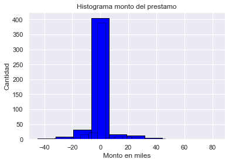

```python
# matplotlib histogram
plt.hist(data_set['YHCSdep'], color = 'blue', edgecolor = 'black',
         )

# seaborn histogram
sns.distplot(data_set['YHCSdep'], hist=True, kde=False,
            color = 'blue',
             hist_kws={'edgecolor':'black'})
# Add labels
plt.title('Histograma monto del prestamo')
plt.xlabel('Monto en miles')
plt.ylabel('Cantidad')
```

```python
test.info()
```

```
<class 'pandas.core.frame.DataFrame'>
Index: 367 entries, LP001015 to LP002989
Data columns (total 18 columns):
 #   Column                       Non-Null Count  Dtype
---  ------                       --------------  -----
 0   Gender                       367 non-null    float64
 1   Married                      367 non-null    int64
 2   Education                    367 non-null    int64
 3   Self_Employed                367 non-null    float64
 4   ApplicantIncome              367 non-null    int64
 5   CoapplicantIncome            367 non-null    int64
 6   Credit_History               367 non-null    float64
 7   Dependents_0                 367 non-null    uint8
 8   Dependents_1                 367 non-null    uint8
 9   Dependents_2                 367 non-null    uint8
 10  Property_Area_Semiurban      367 non-null    uint8
 11  Property_Area_Urban          367 non-null    uint8
 12  ln_monthly_return            367 non-null    float64
 13  ln_total_income              367 non-null    float64
 14  ln_LoanAmount                367 non-null    float64
 15  no360                        367 non-null    uint8
 16  HombresCasadosSdependientes  367 non-null    float64
 17  YHCSdep                      367 non-null    float64
dtypes: float64(8), int64(4), uint8(6)
memory usage: 49.4+ KB
```

#### Sanity Check

A continuación se presenta el Sanity check para la distribución entre Y y N en la columna de destino la distribución entre los valores no cambió mucho (menos del 0,5%)

```
1    0.691667
0    0.308333
Name: Loan_Status, dtype: float64
```

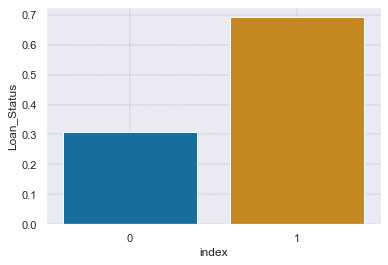

```python
data_set['Loan_Status'].value_counts(normalize=True)
sns.barplot(data = data_set.Loan_Status.value_counts(normalize = True).reset_index(),
            x = 'index',
            y = 'Loan_Status',
            palette=current_palette)
plt.grid(b=True, which='both', axis='both', color='grey', linestyle = '--', linewidth = '0.3')
```

```
1    0.647917
0    0.352083
Name: Married, dtype: float64
```

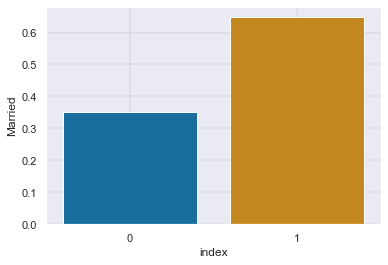

```python
data_set['Married'].value_counts(normalize=True)
sns.barplot(data = data_set.Married.value_counts(normalize = True).reset_index(),
            x = 'index',
            y = 'Married',
            palette=current_palette)
plt.grid(b=True, which='both', axis='both', color='grey', linestyle = '--', linewidth = '0.3')
```

```
1    0.647917
0    0.352083
Name: Married, dtype: float64
```

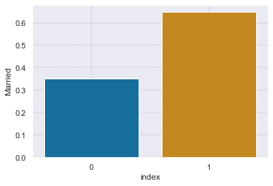

```python
data_set['Married'].value_counts(normalize=True)
sns.barplot(data = data_set.Married.value_counts(normalize = True).reset_index(),
            x = 'index',
            y = 'Married',
            palette=current_palette)
plt.grid(b=True, which='both', axis='both', color='grey', linestyle = '--', linewidth = '0.3')
```

```python
data_set.Married
```

```
Loan_ID
LP001003    1
LP001005    1
LP001006    1
LP001008    0
LP001011    1
           ..
LP002978    0
LP002979    1
LP002983    1
LP002984    1
LP002990    0
Name: Married, Length: 480, dtype: int64
```

```python
for key, value in data_set.items():
    print(key, value)
```

[output not shown]

[output cut: 192 more lines]

[output not shown]

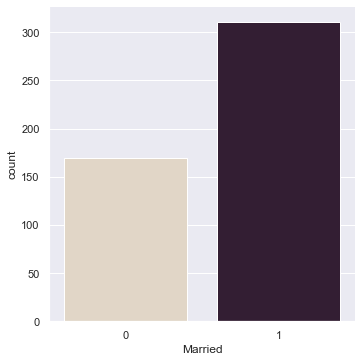

```python
sns.catplot(x="Married", kind="count", palette="ch:.25", data=data_set)
```